# Climate Equity Atlas: Data Documentation

2021-2022 Equity Center Data Team

Michele Claibourn (Director of Equitable Analysis), Chase Dawson, Jacob Goldstein-Greenwood, Jordan House, Khalila Karefa-Kargbo, Lee LeBoeuf, Marisa Lemma, Helena Lindsay, Tolu Odukoya, Michael Salgueiro (Research Programs Manager)

Data Collection Process | Data Collections

## Data Collection Process

In the summer of 2021, we began creating and refining a replicable data collection process to build a collection of data resources for use in our collective work and by anyone in the community. The process is intended to make this work transparent, to provide resources for other to use, and to be highly automated for easier updates.

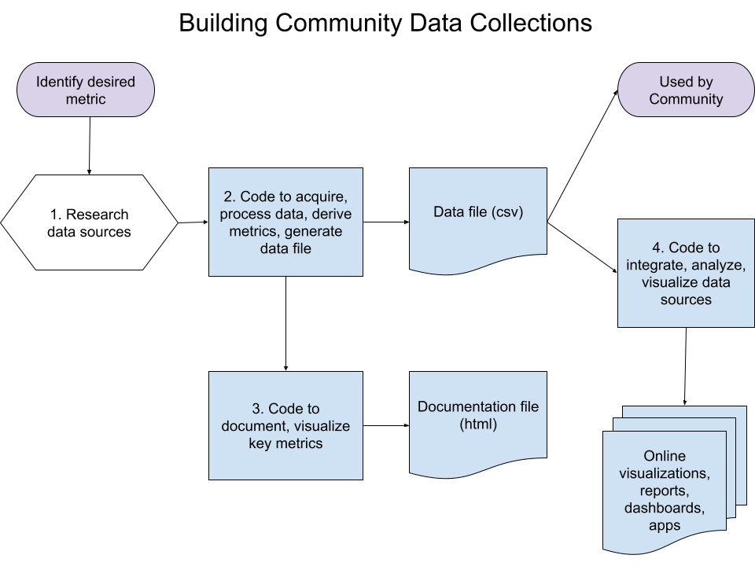

Based on the needs and requests for additional information and data from within our coalition, and those articulated by additional community partners, we

1. Researched available sources, seeking to understand the provenance and genesis of the data (e.g., collected via surveys, captured from satellite imagery, derived from models built around station monitors, etc.), how frequently is it updated, what areas is it available for or could it be aggregated to, and the available variables and measures within the initial sources.
2. Wrote code to acquire the data from source, working to remove as many manual steps as possible; to process the data, filtering to our region, checking data quality, deriving additional measures from included variables, aggregating to administrative boundaries for integration with demographic and population data. Output includes replication code and a csv file of the resulting data.
3. Created code to build a documentation file identifying the source of the data, providing variable definitions, and generating initial visualization of the key metrics. Output includes replication code and a web document providing more details about the data source.

While continuing to add to the current data collections and clean up and refine our work to date, we began step (4) in the spring, integrating the data sources for further analysis and visualization. That work is represented in this atlas and the data stories created for the Picturing Climate exhibit.

## Newly Available Data Collections

To build on the the population data we’ve collected as part of the broader [Equity Atlas Prototype](https://virginiaequitycenter.shinyapps.io/cville-https://virginiaequitycenter.shinyapps.io/cville_equity_atlas/) (e.g., demographic, economic, health, and other social data) and [Shelter in Place](https://virginiaequitycenter.github.io/cvilleequity_covid/SIP/) measures (e.g., food, car, broadband access), the table below provides an overview of the data collections, including data sources, key measures, and motivating questions. The table can be filtered for key topics (climate measures, risk factors, community assets and infrastructure, transportation).

**Click to see Topic Icon details**

- Climate measures, : https://www.flaticon.com/authors/ultimatearm
- Risk factors, : https://www.freepik.com
- Community assets and infrastructure, : https://www.flaticon.com/authors/eucalyp
- Social and economic characteristics, : https://www.flaticon.com/authors/ultimatearm
- Transportation, : https://www.flaticon.com/authors/geotatah

| Icon | Topics | Data Source | Key metrics | Example Questions | Spatial unit | Year | Documentation |
| --- | --- | --- | --- | --- | --- | --- | --- |
|  | Climate measures | USGS, Landsat 8 | Surface temperature median, mean, min, max | Where are summer surface temperatures high or low? | County, tract, block group, block averages | 2014-2021 | Exploration file |
| , | Community assets & infrastructure, Social & economic characteristics | Department of Energy, Low-Income Energy Affordability Data Tool | Average household energy burden, percent of energy burdened households, percent of households burdened in each AMI range, percent of renters burdened, percent of owners burdened | How does energy burden vary across the Charlottesville region? | Tract estimates | 2018 | Documentation file |
|  | Risk factors | Estimated Lead Exposure, VOX and Washington State Department of Health Methodology | Housing risk, poverty risk, lead risk rank | Which neighborhoods have higher risk of lead exposure? | Tract estimates | 2019 | Documentation and Methodology file |
|  | Transportation | EPA, National Walkability Index | Walkability score, street intersection density score, proximity to transit stop score, mix of employment types score, mix of housing and employment score | Which areas are more walking-friendly, with community amenities nearby? | County, tract, block group estimates | 2020 | Exploration file |
|  | Community assets & infrastructure | MRLC, National Land Cover Database | Percent tree canopy, percent impervious surfaces, percent of developed land | What areas have more tree canopy or more impervious surfaces? | Tract, block group, block averages | 2016/2019 | Documentation file |
|  | Climate measures | NOAA, National Centers for Environmental Information | Mininum monthly temperature, maximum monthly temperature, total monthly precipitation | How have monthly temperatures changed over time? How has precipitation varied over years? | County measures | 1895-2000 | Documentation file |
|  | Risk factors | EPA, EJSCREEN | Particulate matter levels, air toxics cancer risk, proximity to traffic, proximity to Treatment Storage and Disposal facilities, ozone levels | What areas in the region are closer to traffic, to waste treatment facilities? | Tract, block group estimates | 2020 | Documentation file |
|  | Community assets & infrastructure | Department of Agriculture, SNAP Retailer Locator | Name, location of food retailers | Where are food retailers located? | Latitude/Longitude | 2021 | Documentation file |
| , | Climate measures, Risk factors | Replication Data for “Disparities in PM2.5 air pollution in the United States” | PM2.5 levels, change in PM2.5 level | How does air quality vary across tracts? | Tract estimates | 1981, 2016 | Documentation file |
| , | Risk factors, Climate measures | FEMA, National Risk Index | Number of events, exposure, and loss due to coastal flooding, droughts, heat waves, hurricanes, riverine flooding, and strong winds | Where do natural hazard risks, like riverine flooding or heat waves, occur across our region? | Tract estimates | 2020 | Documentation file |

[output cut: 14 more lines]